# V506 Lab 6

Review of Critical Functions and Applied Data Analysis

Luis Navarro

Fall 2024

# Readings for this lab

- [R Cookbook](https://rc2e.com/) Chapter 8, Chapter 10 (Complete)
- [R for Data Science](https://r4ds.had.co.nz/index.html) Chapter 10, 11
- [The Epidemiologist R Handbook](https://epirhandbook.com/en/) Chapter 29, 31, 40

# Setup: Clean Environment and Load Libraries

```r
# Clean the environment
rm(list=ls())

# Set your working directory
setwd("/Users/luisenriquenavarro/Library/CloudStorage/OneDrive-IndianaUniversity/V506/Fall24/Lab6/")

# Turn off the scientific notation and set significant digits to 4
options(scipen = 999)
options(digits=4)
# Set seed so random samples are fixed across each run of the code
set.seed(1234)

# Packages Required for the session
library(pacman)
p_load(tidyverse, ggplot2, rmarkdown, rio, here)
```

# Election Results and Income

- For this last lab, we will explore the relationship between election results and household income.
- We will use two public data sources: [MIT Election Lab](https://electionlab.mit.edu/data), and the [American Community Survey (ACS)](https://www.census.gov/programs-surveys/acs/data.html).
- We will:
  - Clean the data
  - Merge the data
  - Summarize the data
  - Visualize the data
  - Analyze the data
- Files available in Canvas.
- For this exercise: only data from the past election (2020).

# Step 1. What is the format of the data frame we want for this analysis?

- In this example we will examine the relationship between election results and sociodemographic characteristics at the county level?
- What is the level of observations we need?
- Ideally, one for each county. (Number of Rows)
- What variables do we need?
- Election results and some measure of income at the county level.
- Final output should have at least 3 components/variables: i) county id (fips code), ii) election result (i.e., percentage vote republican/democrat), iii) a vector of sociodemographic characteristics (e.g., median household income, age, gender, race).

# Clean the data: Election data: Read the data

- Using dplyr, let’s transform the raw data from the internet into workable data frames.

```r
# Load data
lab6_path <- here('/Users/luisenriquenavarro/Library/CloudStorage/OneDrive-IndianaUniversity/V506/Fall24/Lab6')
election_data <- rio::import(file = here(lab6_path,"countypres_2000-2020.csv"))
```

- Get data from the last election

```r
election_data <- election_data %>%
  # keep only data from the last two elections
  filter(year %in% c(2020)) %>%
  # for simplicity, we will only consider republican and democrat vote
  filter(party != "OTHER")
```

- Visualize the structure of the data

```r
election_data %>% head(n = 10)
```

```
##    year   state state_po county_name county_fips       office         candidate
## 1  2020 ALABAMA       AL     AUTAUGA        1001 US PRESIDENT JOSEPH R BIDEN JR
## 2  2020 ALABAMA       AL     AUTAUGA        1001 US PRESIDENT    DONALD J TRUMP
## 3  2020 ALABAMA       AL     BALDWIN        1003 US PRESIDENT JOSEPH R BIDEN JR
## 4  2020 ALABAMA       AL     BALDWIN        1003 US PRESIDENT    DONALD J TRUMP
## 5  2020 ALABAMA       AL     BARBOUR        1005 US PRESIDENT JOSEPH R BIDEN JR
## 6  2020 ALABAMA       AL     BARBOUR        1005 US PRESIDENT    DONALD J TRUMP
## 7  2020 ALABAMA       AL        BIBB        1007 US PRESIDENT JOSEPH R BIDEN JR
## 8  2020 ALABAMA       AL        BIBB        1007 US PRESIDENT    DONALD J TRUMP
## 9  2020 ALABAMA       AL      BLOUNT        1009 US PRESIDENT JOSEPH R BIDEN JR
## 10 2020 ALABAMA       AL      BLOUNT        1009 US PRESIDENT    DONALD J TRUMP
##         party candidatevotes totalvotes  version  mode
## 1    DEMOCRAT           7503      27770 20220315 TOTAL
## 2  REPUBLICAN          19838      27770 20220315 TOTAL
## 3    DEMOCRAT          24578     109679 20220315 TOTAL
## 4  REPUBLICAN          83544     109679 20220315 TOTAL
## 5    DEMOCRAT           4816      10518 20220315 TOTAL
## 6  REPUBLICAN           5622      10518 20220315 TOTAL
## 7    DEMOCRAT           1986       9595 20220315 TOTAL
## 8  REPUBLICAN           7525       9595 20220315 TOTAL
## 9    DEMOCRAT           2640      27588 20220315 TOTAL
## 10 REPUBLICAN          24711      27588 20220315 TOTAL
```

- Create a template of counties. We will merge all the clean variables into this data set.

```r
# Create tempalte of county governments
county_template <- election_data %>%
  # choose only the variables we need. In this case: county fips and year. State and county name are details we might need for the analysis.
  select(state, county_name, county_fips) %>%
  # Group data. county_fips uniquely identify observations in this data frame
  group_by(state, county_fips) %>%
  # Holding the grouping constant, get the county name
  summarize(county_name = first(county_name))
```

```r
# Explore the template
county_template %>%
  head(n = 10)
```

```
## # A tibble: 10 × 3
## # Groups:   state [1]
##    state   county_fips county_name
##    <chr>         <int> <chr>
##  1 ALABAMA        1001 AUTAUGA
##  2 ALABAMA        1003 BALDWIN
##  3 ALABAMA        1005 BARBOUR
##  4 ALABAMA        1007 BIBB
##  5 ALABAMA        1009 BLOUNT
##  6 ALABAMA        1011 BULLOCK
##  7 ALABAMA        1013 BUTLER
##  8 ALABAMA        1015 CALHOUN
##  9 ALABAMA        1017 CHAMBERS
## 10 ALABAMA        1019 CHEROKEE
```

```r
# Explore the template: number of counties by state
county_template %>%
  ungroup() %>%
  group_by(state) %>%
  summarize(`Number of Counties` = n()) %>%
  arrange(-`Number of Counties`) %>%
  head(n = 10)
```

```
## # A tibble: 10 × 2
##    state          `Number of Counties`
##    <chr>                         <int>
##  1 TEXAS                           254
##  2 GEORGIA                         159
##  3 VIRGINIA                        133
##  4 KENTUCKY                        120
##  5 MISSOURI                        116
##  6 KANSAS                          105
##  7 ILLINOIS                        102
##  8 NORTH CAROLINA                  100
##  9 IOWA                             99
## 10 TENNESSEE                        95
```

# Clean the Data: Election Results

- Create a variable for the percentage of votes for each party at the county level. Also create a dummy variable equal to one if the majority of the county voted republican.

```r
# use group by to compute variables by county and election (year)
election_data_clean <- election_data %>%
  # Group data by county. Each row identifies a county - candidate. We want to compute totals by county. We need to group.
  group_by(county_fips) %>%
  # compute the percentage of vote per candidate or party
  mutate(percent_vote = candidatevotes/totalvotes) %>%
  # get variable that determines who got the majority of the vote
  # remember the variable is still grouped by county and year
  mutate(majority_vote = ifelse(percent_vote == max(percent_vote), party, NA)) %>%
  # keep only the observation from the majority votes
  filter(is.na(majority_vote)==FALSE) %>%
  # create a republican dummy variable
  mutate(republican = ifelse(majority_vote == "REPUBLICAN", 1,0)) %>%
  # break the grouping.
  ungroup() %>%
  # only keep state, county_fips, party, candidatevotes and total votes
  select(county_fips, party, percent_vote, candidatevotes, totalvotes)

election_data_clean %>%
  head(n = 10)
```

```
## # A tibble: 10 × 5
##    county_fips party      percent_vote candidatevotes totalvotes
##          <int> <chr>             <dbl>          <int>      <int>
##  1        1001 REPUBLICAN        0.714          19838      27770
##  2        1003 REPUBLICAN        0.762          83544     109679
##  3        1005 REPUBLICAN        0.535           5622      10518
##  4        1007 REPUBLICAN        0.784           7525       9595
##  5        1009 REPUBLICAN        0.896          24711      27588
##  6        1011 DEMOCRAT          0.747           3446       4613
##  7        1013 REPUBLICAN        0.575           5458       9488
##  8        1015 REPUBLICAN        0.688          35101      50983
##  9        1017 REPUBLICAN        0.573           8753      15284
## 10        1019 REPUBLICAN        0.860          10583      12301
```

# Clean the data: Sociodemographic Characteristics from the Census

- Load data from the ACS.
- You can directly download data from the census into R.
- Check library [tidycensus](https://walker-data.com/census-r/an-introduction-to-tidycensus.html) and this [book](https://walker-data.com/census-r/index.html).
- Check appendix of the slides for example code. Also, great tool to make maps.
- Sample data: sociodemographic characteristics of all U.S. counties in 2019.
- Variables: population total, population female, population black or african american, median age, median household income.

# Clean the data: Sociodemographic Characteristics from the Census

```r
# read the data
county_data_raw <- rio::import(here(lab6_path, 'county_data.csv'))

# view the data
county_data_raw %>% head(n = 10)
```

```
##    county_fips                    NAME                variable estimate
## 1         1001 Autauga County, Alabama                  female  28446.0
## 2         1001 Autauga County, Alabama              age_median     38.2
## 3         1001 Autauga County, Alabama              population  55380.0
## 4         1001 Autauga County, Alabama                   black  10538.0
## 5         1001 Autauga County, Alabama            college_grad   6019.0
## 6         1001 Autauga County, Alabama median_household_income  58731.0
## 7         1003 Baldwin County, Alabama                  female 109334.0
## 8         1003 Baldwin County, Alabama              age_median     43.0
## 9         1003 Baldwin County, Alabama              population 212830.0
## 10        1003 Baldwin County, Alabama                   black  19718.0
```

- This data comes in long format.
- For the analysis, we need it wide.

```r
# clean the county data
county_data <- county_data_raw %>%
  # remove name, we identify by county fips
  select(-NAME) %>%
  # use spread to reshape the data
  # syntax: spread(columns, values). First the variable that determines the columns. Next the values.
  spread(variable, estimate) %>%
  # calculate sociodemographics as % of the population
  mutate(female = 100*female/population,
         black = 100*black/population,
         college = 100*college_grad/population)
```

# Putting everything together

- Let’s recall our template. Check the names of the variables that identify observations in the template. Verify this have the same name and class on the data sets we will merge.
- Template for the merge.

```r
# view the data
county_template %>% head(n = 6)
```

```
## # A tibble: 6 × 3
## # Groups:   state [1]
##   state   county_fips county_name
##   <chr>         <int> <chr>
## 1 ALABAMA        1001 AUTAUGA
## 2 ALABAMA        1003 BALDWIN
## 3 ALABAMA        1005 BARBOUR
## 4 ALABAMA        1007 BIBB
## 5 ALABAMA        1009 BLOUNT
## 6 ALABAMA        1011 BULLOCK
```

- Election data.

```r
# view the data
election_data_clean %>% head(n = 6)
```

```
## # A tibble: 6 × 5
##   county_fips party      percent_vote candidatevotes totalvotes
##         <int> <chr>             <dbl>          <int>      <int>
## 1        1001 REPUBLICAN        0.714          19838      27770
## 2        1003 REPUBLICAN        0.762          83544     109679
## 3        1005 REPUBLICAN        0.535           5622      10518
## 4        1007 REPUBLICAN        0.784           7525       9595
## 5        1009 REPUBLICAN        0.896          24711      27588
## 6        1011 DEMOCRAT          0.747           3446       4613
```

- Sociodemographic data

```r
# view the data
county_data %>% head(n = 6)
```

```
##   county_fips age_median  black college_grad female median_household_income
## 1        1001       38.2 19.029         6019  51.37                   58731
## 2        1003       43.0  9.265        31801  51.37                   58320
## 3        1005       40.4 47.577         1367  47.08                   32525
## 4        1007       40.9 22.291         1043  45.98                   47542
## 5        1009       40.7  1.609         3432  50.60                   49358
## 6        1011       40.2 74.805          527  45.64                   37785
##   population college
## 1      55380  10.869
## 2     212830  14.942
## 3      25361   5.390
## 4      22493   4.637
## 5      57681   5.950
## 6      10248   5.142
```

# Putting everything together: merge and left_join

- Merge all the data frames into the template

```r
data_analysis <- county_template %>%
  # Merge clean election data
  left_join(election_data_clean, by = "county_fips", relationship = "one-to-one") %>%
  # Merge clean gdp data
  left_join(county_data, by = "county_fips", relationship = "one-to-one") %>%
  # Variable to make the visualization easier
  # create variable called vote republican
  # percentage of republican vote and label with the party with the vote majority
  mutate(republican = ifelse(party == "REPUBLICAN", 1,0),
         vote_rep = ifelse(republican == 1, percent_vote, 1 - percent_vote),
         party = party %>% as.factor()) %>%
  # For simplicity, let's exclude DC, ALASKA, and HAWAII
  filter(!state %in% c("DISTRICT OF COLUMBIA", "ALASKA", "HAWAII")) %>%
  # also exclude kansas city and counties without identifier
  filter(county_fips != 2938000) %>%
  filter(is.na(county_fips)==FALSE)
```

```r
data_analysis %>% glimpse()
```

```
## Rows: 3,107
## Columns: 16
## Groups: state [48]
## $ state                   <chr> "ALABAMA", "ALABAMA", "ALABAMA", "ALABAMA", "A…
## $ county_fips             <int> 1001, 1003, 1005, 1007, 1009, 1011, 1013, 1015…
## $ county_name             <chr> "AUTAUGA", "BALDWIN", "BARBOUR", "BIBB", "BLOU…
## $ party                   <fct> REPUBLICAN, REPUBLICAN, REPUBLICAN, REPUBLICAN…
## $ percent_vote            <dbl> 0.7144, 0.7617, 0.5345, 0.7843, 0.8957, 0.7470…
## $ candidatevotes          <int> 19838, 83544, 5622, 7525, 24711, 3446, 5458, 3…
## $ totalvotes              <int> 27770, 109679, 10518, 9595, 27588, 4613, 9488,…
## $ age_median              <dbl> 38.2, 43.0, 40.4, 40.9, 40.7, 40.2, 40.8, 39.6…
## $ black                   <dbl> 19.029, 9.265, 47.577, 22.291, 1.609, 74.805, …
## $ college_grad            <dbl> 6019, 31801, 1367, 1043, 3432, 527, 1343, 8311…
## $ female                  <dbl> 51.37, 51.37, 47.08, 45.98, 50.60, 45.64, 54.2…
## $ median_household_income <dbl> 58731, 58320, 32525, 47542, 49358, 37785, 4068…
## $ population              <dbl> 55380, 212830, 25361, 22493, 57681, 10248, 198…
## $ college                 <dbl> 10.869, 14.942, 5.390, 4.637, 5.950, 5.142, 6.…
## $ republican              <dbl> 1, 1, 1, 1, 1, 0, 1, 1, 1, 1, 1, 1, 1, 1, 1, 1…
## $ vote_rep                <dbl> 0.7144, 0.7617, 0.5345, 0.7843, 0.8957, 0.2530…
```

- Data cleaning: DONE

# Data Analysis.

- Now that our data is finally clean, we can use it to answer some questions.
- For example: How can we characterize the age and income profile of voters by state?
- What do we need to do to answer that question?

# Data Analysis 1: Descriptive Statistics by State

```r
descriptive_stats_state <- data_analysis %>%
  # group the data by state
  group_by(state) %>%
  # use summarize to compute some descriptive statistics
  summarize(vote_rep = mean(vote_rep, na.rm = TRUE),
            age_median = mean(age_median, na.rm = TRUE),
            # you can also compute weighted averages. Read the documentation of weighted.mean
            mhi = weighted.mean(median_household_income, population, na.rm = TRUE),
            republican_counties = sum(republican, na.rm = TRUE),
            college = mean(college, na.rm = TRUE),
            total_pop = sum(population, na.rm = TRUE)) %>%
  # Express population in millions
  mutate(total_pop = total_pop/1000000) %>%
  # sort by size
  arrange(-total_pop)

# View the data
descriptive_stats_state %>% head(n = 10)
```

```
## # A tibble: 10 × 7
##    state        vote_rep age_median    mhi republican_counties college total_pop
##    <chr>           <dbl>      <dbl>  <dbl>               <dbl>   <dbl>     <dbl>
##  1 CALIFORNIA      0.454       39.9 77311.                  23   12.0      39.3
##  2 TEXAS           0.745       39.2 63141.                 232    8.75     28.3
##  3 FLORIDA         0.635       43.8 56239.                  55   10.3      20.9
##  4 NEW YORK        0.513       41.6 72408.                  41   11.0      19.6
##  5 PENNSYLVANIA    0.638       43.3 63593.                  54   10.4      12.8
##  6 ILLINOIS        0.656       41.9 67934.                  88    9.65     12.8
##  7 OHIO            0.676       41.0 57793.                  81    8.88     11.7
##  8 GEORGIA         0.450       39.9 60583.                 138    7.64     10.4
##  9 NORTH CAROL…    0.477       42.7 56376.                  76   10.1      10.3
## 10 MICHIGAN        0.599       44.8 58642.                  72    9.95      9.97
```

- Note we can show this table as a bar chart.

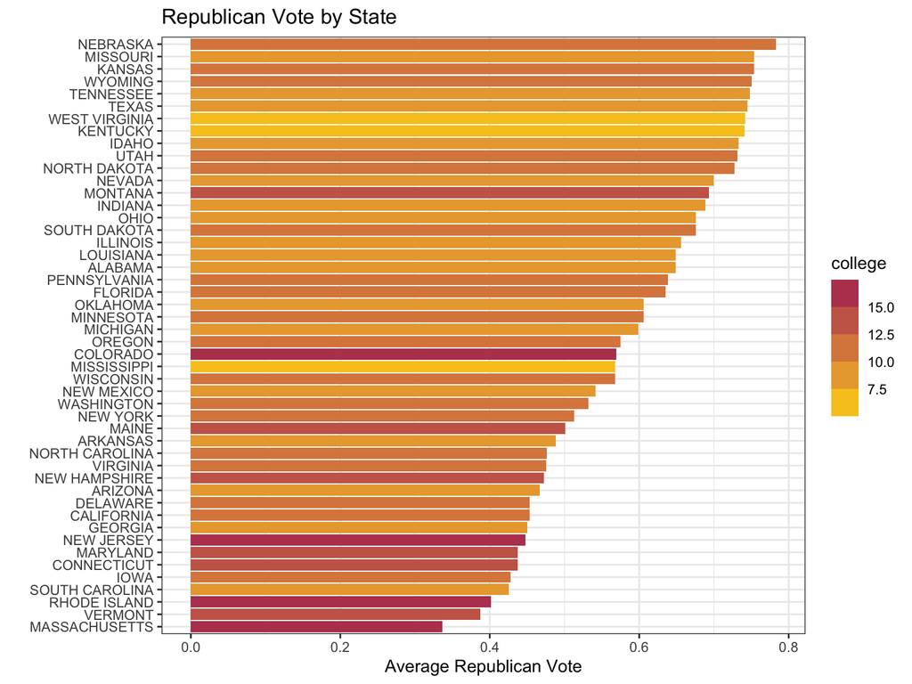

```r
# Bar chart
# get the data set with the information we want to plot
descriptive_stats_state %>%
  # set the aesthetic mappings. Specify which variables determine the values on the x-y axis, as well as any features of the graph that vary across the values of certain variables.
  ggplot(mapping = aes(y = reorder(state, vote_rep),
                       x = vote_rep, fill = college)) +
  # specify we want a bar chart
  geom_bar(stat = "identity") +
  # labels and formatting
  labs(x = "Average Republican Vote",
       y = "",
       title = "Republican Vote by State") +
  theme_bw() +
  scale_fill_binned(low = "gold", high = "maroon")
```

- How many counties voted republican or democrat?

```r
votes_by_county <- data_analysis %>%
  group_by(party) %>%
  # use summarize to compute some descriptive statistics
  summarize(number_counties = n_distinct(county_fips))

votes_by_county
```

```
## # A tibble: 2 × 2
##   party      number_counties
##   <fct>                <int>
## 1 DEMOCRAT               539
## 2 REPUBLICAN            2568
```

# Visualize the data

- What is the distribution of Median Household Income (MHI) by voting preferences?
- How do we answer this question with a graph?
- Let’s compare the distribution of income across two sub-populations of US counties: i) counties with majority vote republican, and ii) counties with majority vote democrat.
- Which graphs can we use to compare the distribution of two sub-populations?

# Visualize the data

- We can do a boxplot:

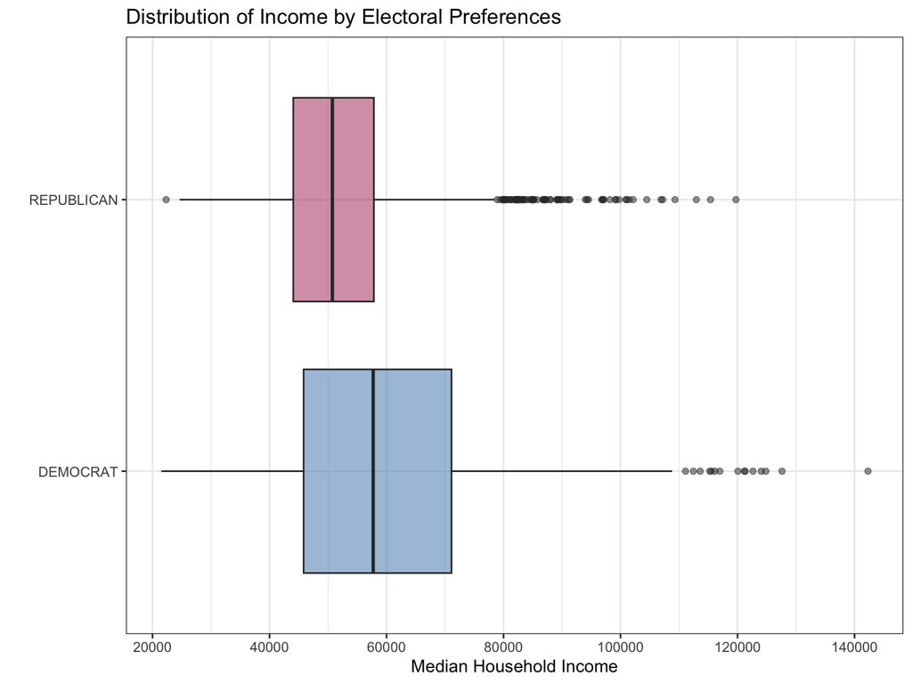

```r
mhi_box <- data_analysis %>%
  ggplot(mapping = aes(x = median_household_income, y = party, fill = party)) +
  geom_boxplot(alpha = 0.5) +
  labs(x = "Median Household Income", y = "",
       title = "Distribution of Income by Electoral Preferences") +
  scale_fill_manual(values = c("steelblue", "maroon")) +
  scale_x_continuous(n.breaks = 10) +
  theme_bw() + theme(legend.position = "none")


# show the graph
mhi_box
```

- Also a histogram

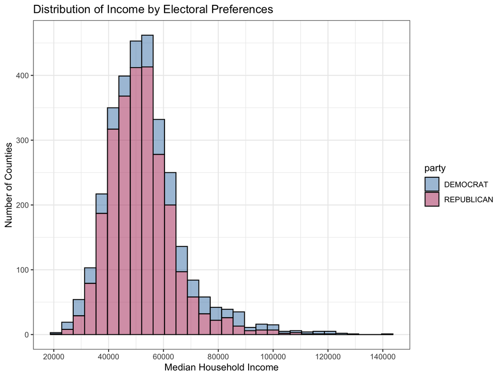

```r
mhi_hist <- data_analysis %>%
  ggplot(mapping = aes(x = median_household_income,fill = party)) +
  geom_histogram(alpha = 0.5, color = "black") +
  labs(x = "Median Household Income", y = "Number of Counties",
       title = "Distribution of Income by Electoral Preferences") +
  theme_bw() +
  scale_fill_manual(values = c("steelblue", "maroon")) +
  scale_x_continuous(n.breaks = 10)

# show the graph
mhi_hist
```

- Which is one is better?
- Which one provides an easier representation of the differences in the distribution of income?

# Visualize the data

- What is the relationship between median household income and educational attainment, by voting preferences?

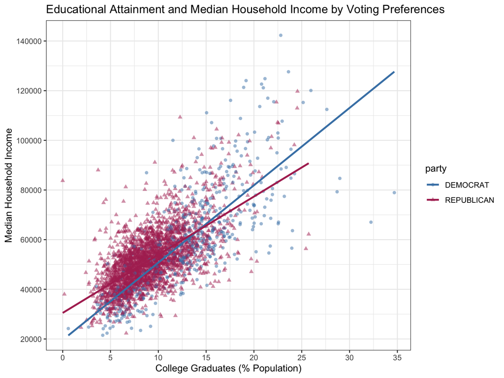

```r
data_analysis %>%
  ggplot(mapping = aes(x = college, y = median_household_income,
                       fill = party, color = party, shape = party)) +
  geom_point(alpha = 0.5) +
  geom_smooth(method = "lm", se = FALSE) +
  labs(x = "College Graduates (% Population)", y = "Median Household Income",
       title = "Educational Attainment and Median Household Income by Voting Preferences") +
  scale_color_manual(values = c("steelblue", "maroon")) +
  scale_x_continuous(n.breaks = 10) +
  scale_y_continuous(n.breaks = 10) +
  theme_bw()
```

- Is this visualization clear? Not really.
- We can smooth the data using a transformation of the income measurement.
- We can take the natural logarithm. This re-scales the distribution of the variable, without changing the relative position of observations among each other. In mathematics, this is known as a [monotonic transformation](https://en.wikipedia.org/wiki/Monotonic_function) and is widely used in statistics, economics, and social science.

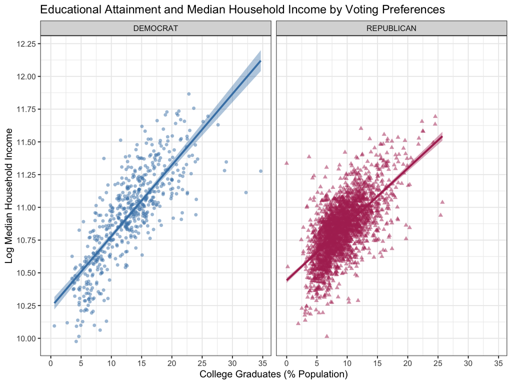

```r
data_analysis %>%
  # add variable we want to graph
  mutate(log_mhi = log(median_household_income)) %>%
  # ser aesthetic mappings
  ggplot(mapping = aes(x = college, y = log_mhi,
                       fill = party, color = party, shape = party)) +
  geom_point(alpha = 0.5) +
  # geom_smooth adds the linear relationship between the variables (it shows the predicted values of a linear regression of y = f(x))
  geom_smooth(method = "lm") +
  labs(x = "College Graduates (% Population)", y = "Log Median Household Income",
       title = "Educational Attainment and Median Household Income by Voting Preferences") +
  scale_color_manual(values = c("steelblue", "maroon")) +
  scale_fill_manual(values = c("steelblue", "maroon")) +
  scale_x_continuous(n.breaks = 10) +
  scale_y_continuous(n.breaks = 10) +
  facet_wrap(~party, ncol = 2) +
    theme_bw() +
  # remove legend
  theme(legend.position = "none")
```

- Is this visualization better?
- What can we infer from this graph?
- Let’s try another thing. Use the state data

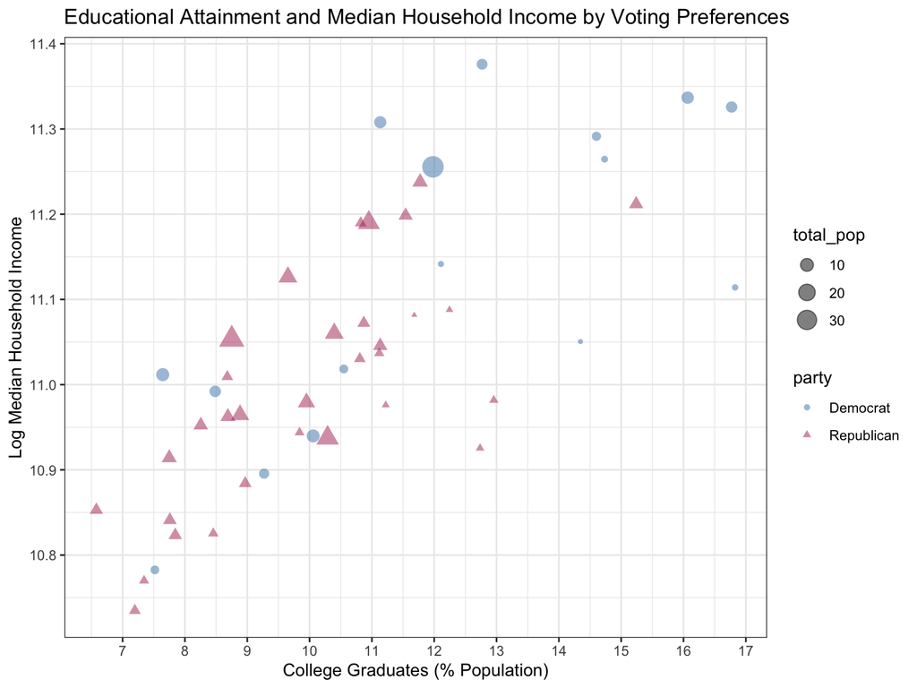

```r
descriptive_stats_state %>%
  mutate(log_mhi = log(mhi)) %>%
  mutate(party = ifelse(vote_rep >= 0.50, "Republican", "Democrat")) %>%
  ggplot(mapping = aes(x = college, y = log_mhi,
                       fill = party, color = party, shape = party, size = total_pop)) +
  geom_point(alpha = 0.5) +
  labs(x = "College Graduates (% Population)", y = "Log Median Household Income",
       title = "Educational Attainment and Median Household Income by Voting Preferences") +
  scale_color_manual(values = c("steelblue", "maroon")) +
  scale_x_continuous(n.breaks = 10) +
  scale_y_continuous(n.breaks = 10) +
  theme_bw()
```

# Hypothesis Testing:

- We can provide some formal answers to some questions by conducting an hypothesis test.
- Are counties with more college graduates more likely to vote democrat ?
- First, let’s compute split the sample between counties whose percentage of the population with a college degree is above/below the national median.

```r
mean_diff_college <- data_analysis %>%
  # dummy variable = 1 if county has majority of population female
  mutate(college_majority = ifelse(college >= median(data_analysis$college), "Above Median", "Below Median")) %>%
  # Group all counties with majority female
  group_by(college_majority) %>%
  # summarize the data. Get the average vote for each county
  summarize(mean_vote = mean(vote_rep, na.rm = TRUE),
            sd_vote = sd(vote_rep, na.rm = TRUE),
            total_counties = n()) %>%
  # build standard errors manually
  mutate(se = sd_vote/sqrt(total_counties)) %>%
  # build confidence intervals manually
  mutate(mean_low = mean_vote - 1.96*se,
         mean_high = mean_vote + 1.96*se)
```

- Visual representation of the mean difference.

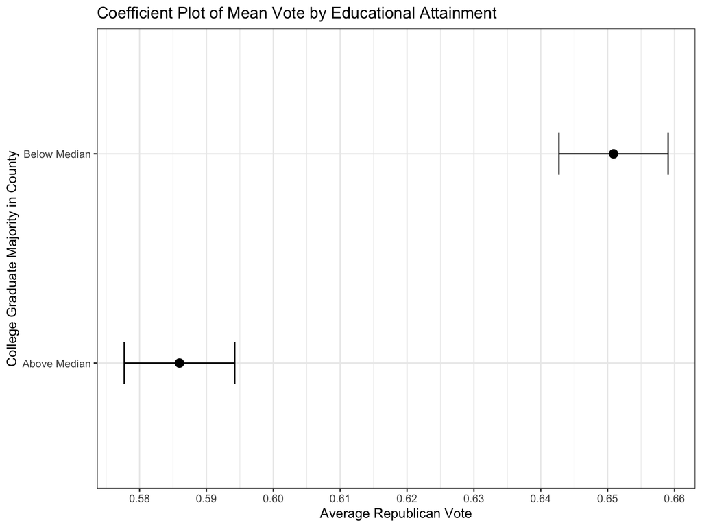

```r
ggplot(mean_diff_college, aes(y = college_majority, x = mean_vote)) +
  geom_point(size = 3) +
  # geom errorbar allows to include the confidence intervals
  geom_errorbar(aes(xmin = mean_low, xmax = mean_high), width = 0.2) +
  labs(
    y = "College Graduate Majority in County",
    x = "Average Republican Vote",
    title = "Coefficient Plot of Mean Vote by Educational Attainment"
  ) +
  scale_x_continuous(n.breaks = 10) +
  theme_bw()
```

- Informal Test: compute the mean difference.

```r
# Data frame with the results from the estimation
mean_diff_college %>%
  # keep only the mean
  select(college_majority, mean_vote) %>%
  # reshape data wide to compute the mean difference
  spread(college_majority, mean_vote) %>%
  # compute the mean difference
  mutate(`Mean Difference` = `Above Median` - `Below Median`)
```

```
## # A tibble: 1 × 3
##   `Above Median` `Below Median` `Mean Difference`
##            <dbl>          <dbl>             <dbl>
## 1          0.586          0.651           -0.0649
```

- Formal Test: hypothesis test on whether the mean difference shown above is statistically significant.
- We need a test statistic.

$$t = \frac{\bar{X_1}-\bar{X_2}}{(S_{X_1}
+ S_{X_2})^{1/2}}$$

```r
data_test <- data_analysis %>%
  mutate(college_majority = ifelse(college >= median(data_analysis$college), "Above Median", "Below Median"))

# define the vectors of data from each subpopulation
vote_rep_above_median <- data_test %>% filter(college_majority == "Above Median") %>% pull(vote_rep)
vote_rep_below_median <- data_test %>% filter(college_majority == "Below Median") %>% pull(vote_rep)

# run the hypothesis test
college_test <- t.test(vote_rep_above_median, vote_rep_below_median)
college_test
```

```
##
##  Welch Two Sample t-test
##
## data:  vote_rep_above_median and vote_rep_below_median
## t = -11, df = 3105, p-value <0.0000000000000002
## alternative hypothesis: true difference in means is not equal to 0
## 95 percent confidence interval:
##  -0.07653 -0.05328
## sample estimates:
## mean of x mean of y
##    0.5860    0.6509
```

- Visual representation of the t-test.

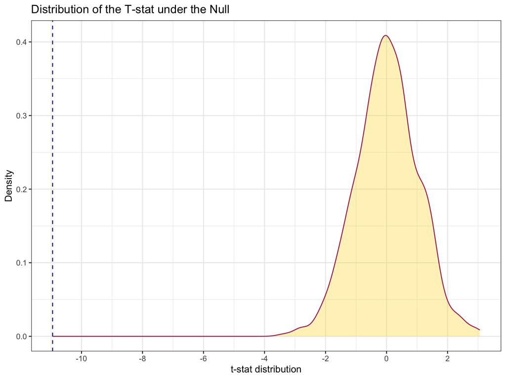

```r
# visual representation of the two sample t-test
degfree = college_test$parameter
t_stat = college_test$statistic
# Compute the distribution of test-stastic under the null
t_dist_null <- data.frame(x = rt(n=1000, df =degfree)) %>% tibble()

## Ggplot
t_dist_plot <- ggplot(t_dist_null, aes(x = x)) +
             geom_density(color = "maroon", fill = "gold", alpha = 0.3) +
             geom_vline(xintercept = t_stat, color = "navy", linetype = "dashed")+
             theme_bw() +
             labs(title = "Distribution of the T-stat under the Null", x = "t-stat distribution",y = "Density") +
             scale_x_continuous(n.breaks = 10)
t_dist_plot
```

# T-test and Linear Regression

- You can do the math and verify that:

$$\beta_1 = E[VoteRep |
CollegeAboveMedian = 1] - E[VoteRep | CollegeAboveMedian =
0]$$

- The command `lm` estimates a linear regression model.
- Syntax: `lm(formula = dependent variable ~ independent variables, data = data)`

```r
t_test_lm <- lm(formula = vote_rep ~ college_majority,
                data = data_test)

# Show the regression output
t_test_lm %>% summary()
```

```
##
## Call:
## lm(formula = vote_rep ~ college_majority, data = data_test)
##
## Residuals:
##     Min      1Q  Median      3Q     Max
## -0.5349 -0.1167  0.0244  0.1274  0.3758
##
## Coefficients:
##                              Estimate Std. Error t value            Pr(>|t|)
## (Intercept)                   0.58597    0.00419     140 <0.0000000000000002
## college_majorityBelow Median  0.06491    0.00593      11 <0.0000000000000002
##
## (Intercept)                  ***
## college_majorityBelow Median ***
## ---
## Signif. codes:  0 '***' 0.001 '**' 0.01 '*' 0.05 '.' 0.1 ' ' 1
##
## Residual standard error: 0.165 on 3105 degrees of freedom
## Multiple R-squared:  0.0372, Adjusted R-squared:  0.0369
## F-statistic:  120 on 1 and 3105 DF,  p-value: <0.0000000000000002
```

- Check the estimated coefficient for $\beta_0$ (i.e., the intercept). Does it matches some of the averages we manually computed? Which one and why?
- Check the estimated coefficient for $\beta_1$. Does it matches the mean difference we manually computed?
- **NOTE** beware this interpretation is only valid for doing regression on dummy variables. With discrete and continuous variables intuition is similar but interpretation is slightly different.
- Useful to keep in mind the “calculus interpretation” of regression coefficients.

$$y = \beta_0 + \beta_1 x + e$$

$$\beta_1 = \frac{dy}{dx}$$

# Linear regression

- We are not going to cover what a regression is, the mechanics, etc.
- The goal is to demonstrate the R command so that you have a resource for when regressions are covered later in this course.
- Simple linear regression using the data we cleaned.
- In R, a “formula” is denoted as “y ~ x” (similar to the “y = x”, just note that the tilde is used here).
- A multivariate regression (the variation in y depends on more than one variable) can be done by adding the additional variables to the formula (y ~ x + z, for example).
- The basic form of a simple linear regression is the following:

$$y_i = \alpha + \beta x_i +
e_i$$

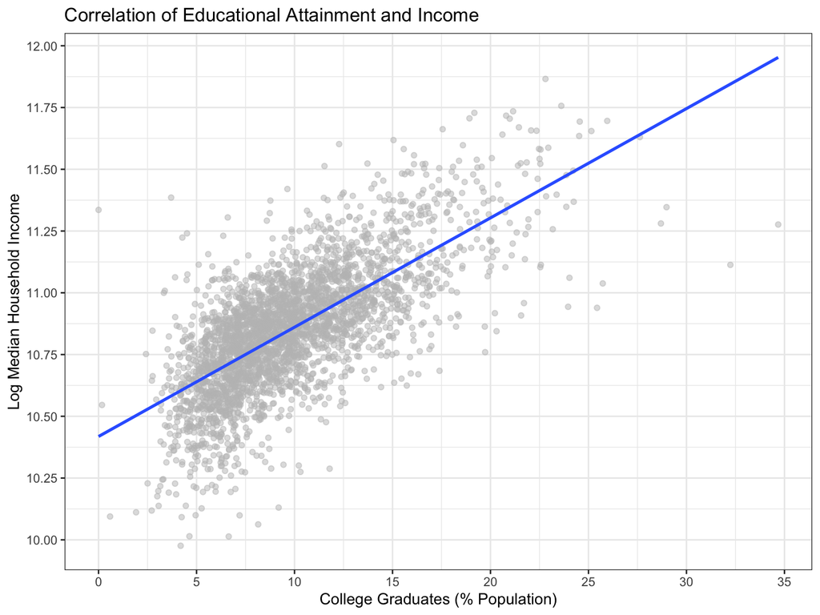

```r
data_analysis %>%
  mutate(log_mhi = log(median_household_income)) %>%
  ggplot(mapping = aes(x=college, y = log_mhi))+
                    geom_point(alpha = 0.5, col = "gray") +
                    geom_smooth(method = "lm", se = FALSE)+
                    labs(x ="College Graduates (% Population)", y="Log Median Household Income", title = "Correlation of Educational Attainment and Income")+
                    theme_bw() + scale_x_continuous(n.breaks = 10) + scale_y_continuous(n.breaks = 10)
```

- The relationship between *y* and *x* can be modeled by a straight line with some error *e*.
- Model Estimation:

```r
reg1 = lm(median_household_income ~ college,
          data = data_analysis)
summary(reg1)
```

```
##
## Call:
## lm(formula = median_household_income ~ college, data = data_analysis)
##
## Residuals:
##    Min     1Q Median     3Q    Max
## -43343  -6190   -875   5380  55917
##
## Coefficients:
##             Estimate Std. Error t value            Pr(>|t|)
## (Intercept)  28379.0      480.2    59.1 <0.0000000000000002 ***
## college       2543.5       45.5    55.9 <0.0000000000000002 ***
## ---
## Signif. codes:  0 '***' 0.001 '**' 0.01 '*' 0.05 '.' 0.1 ' ' 1
##
## Residual standard error: 9950 on 3105 degrees of freedom
## Multiple R-squared:  0.502,  Adjusted R-squared:  0.501
## F-statistic: 3.12e+03 on 1 and 3105 DF,  p-value: <0.0000000000000002
```

*Coefficient Interpretation*

- An increase in one percentage point on the proportion of college graduates in the county, is associated with a increase of $ 2,543 in annual median household income.
- How do you know if this effect is big?
- Take the descriptive statistics of the dependent variable.

```r
depvar_stats <- data_analysis %>% ungroup() %>%
  summarize(Mean = mean(median_household_income, na.rm = TRUE),
            SD = sd(median_household_income, na.rm = TRUE)) %>%
  # manually compute an increase of one SD from the mean
  mutate(`Mean+SD` = Mean + SD)

depvar_stats
```

```
## # A tibble: 1 × 3
##     Mean     SD `Mean+SD`
##    <dbl>  <dbl>     <dbl>
## 1 53295. 14094.    67389.
```

- Take the ratio of the beta coefficient (increase on $y$ for an increase on $x$) and the standard deviation of $y$ (measure of the variability of the dependent variable)

```r
# compute effect size
beta_coef <- coef(reg1)['college'] %>% as.double()
sd_depvar <- depvar_stats$SD

eff_size <- beta_coef/sd_depvar
eff_size
```

```
## [1] 0.1805
```

- An increase of one standard deviation from the mean, implies passing from $53,295 to $67,389.
- An increase of 1% on educational attainment, leads to an increase of $2,543. This is equivalent to passing from $53,295 to $55,838
- The estimated effect is equivalent to deviation of roughly 0.18 SD.

**Model Prediction and Goodness of fit**

```r
data.frame(reg1$model,
           PredictedMHI= reg1$fitted.values,
           Residuals = reg1$residuals) %>%
           mutate(SquaredRes = Residuals^2) %>% arrange(by_group = SquaredRes) %>% head(n=10)
```

```
##    median_household_income college PredictedMHI Residuals SquaredRes
## 1                    43145   5.803        43139     5.783      33.44
## 2                    54858  10.408        54851     6.904      47.66
## 3                    59329  12.172        59337    -8.105      65.70
## 4                    49779   8.407        49762    16.570     274.57
## 5                    43923   6.103        43903    20.472     419.12
## 6                    48009   7.726        48030   -21.130     446.49
## 7                    65492  14.601        65517   -24.613     605.81
## 8                    49349   8.232        49316    33.267    1106.69
## 9                    47500   7.531        47534   -33.667    1133.47
## 10                   40485   4.746        40451    34.311    1177.23
```

$$\beta_1 =
\frac{cov(x,y)}{var(x)}$$

- Regression coefficients capture the correlation of two variables, adjusting for the variance of the explanatory variable.

**Extra**

- Multivariate regression:

```r
reg2 = lm(median_household_income ~ college + age_median + black + female, data = data_analysis)
summary(reg2)
```

```
##
## Call:
## lm(formula = median_household_income ~ college + age_median +
##     black + female, data = data_analysis)
##
## Residuals:
##    Min     1Q Median     3Q    Max
## -44230  -5336   -501   4703  58124
##
## Coefficients:
##             Estimate Std. Error t value             Pr(>|t|)
## (Intercept)  64260.9     3837.3   16.75 < 0.0000000000000002 ***
## college       2487.5       44.2   56.32 < 0.0000000000000002 ***
## age_median    -459.8       31.9  -14.43 < 0.0000000000000002 ***
## black         -166.6       12.1  -13.78 < 0.0000000000000002 ***
## female        -295.2       74.4   -3.97             0.000074 ***
## ---
## Signif. codes:  0 '***' 0.001 '**' 0.01 '*' 0.05 '.' 0.1 ' ' 1
##
## Residual standard error: 9400 on 3102 degrees of freedom
## Multiple R-squared:  0.555,  Adjusted R-squared:  0.555
## F-statistic:  969 on 4 and 3102 DF,  p-value: <0.0000000000000002
```

# Extra: Mean Estimation using lm function

- Regression is way of computing conditional averages.

$$E[y |x] = \beta_0 + \beta_1
x$$

- Example: unconditional average
- Suppose you want to estimate the sample mean of median household income, and obtain the standard error, confidence interval, and p-value of the point estimate.
- We have covered how to do that with the *t.test* function.
- One sample t-test where the null hypothesis is equal to zero.

```r
t.test(data_analysis$median_household_income, mu = 0)
```

```
##
##  One Sample t-test
##
## data:  data_analysis$median_household_income
## t = 211, df = 3106, p-value <0.0000000000000002
## alternative hypothesis: true mean is not equal to 0
## 95 percent confidence interval:
##  52799 53791
## sample estimates:
## mean of x
##     53295
```

- How is this related to linear regression?

$$E[y |x = 0] = \beta_0$$

- We can replicate this same calculation using the *lm* function to estimate a linear regression only using the intercept as explanatory variable.

```r
lm(formula = median_household_income ~ 1, data = data_analysis) %>% summary()
```

```
##
## Call:
## lm(formula = median_household_income ~ 1, data = data_analysis)
##
## Residuals:
##    Min     1Q Median     3Q    Max
## -31791  -9171  -1638   6270  89004
##
## Coefficients:
##             Estimate Std. Error t value            Pr(>|t|)
## (Intercept)    53295        253     211 <0.0000000000000002 ***
## ---
## Signif. codes:  0 '***' 0.001 '**' 0.01 '*' 0.05 '.' 0.1 ' ' 1
##
## Residual standard error: 14100 on 3106 degrees of freedom
```

# Extra: ANOVA

- The Analysis of Variance (ANOVA) shows you the variation of the dependent variable broken into the variation of the regressors and the residuals.
- The ANOVA also reports the test statistic F that compares the mean squares from the independent variables (explained variation) and the mean squares from the error term (unexplained variation).

```r
aov_1 = aov(median_household_income ~ college, data = data_analysis)
aov(reg1)
```

```
## Call:
##    aov(formula = reg1)
##
## Terms:
##                      college    Residuals
## Sum of Squares  309457887694 307518271378
## Deg. of Freedom            1         3105
##
## Residual standard error: 9952
## Estimated effects may be unbalanced
```

```r
summary(aov_1)
```

```
##               Df       Sum Sq      Mean Sq F value              Pr(>F)
## college        1 309457887694 309457887694    3125 <0.0000000000000002 ***
## Residuals   3105 307518271378     99039701
## ---
## Signif. codes:  0 '***' 0.001 '**' 0.01 '*' 0.05 '.' 0.1 ' ' 1
```

```r
9138834959/607837324114
```

```
## [1] 0.01504
```

- The F value is equal to *Mean Sq MHI*/*Mean Sq Residuals*.
- If the null hypothesis is true, any differences between the explained and unexplained variation are due to chance, therefore, the mean squares shout be roughly the same.

```r
aov_2 = aov(median_household_income ~ age_median + black + female, data = data_analysis)
summary(aov_2)
```

```
##               Df       Sum Sq     Mean Sq F value               Pr(>F)
## age_median     1   9138834959  9138834959    51.1      0.0000000000011 ***
## black          1  50768425938 50768425938   284.0 < 0.0000000000000002 ***
## female         1   2375910897  2375910897    13.3              0.00027 ***
## Residuals   3103 554692987279   178760228
## ---
## Signif. codes:  0 '***' 0.001 '**' 0.01 '*' 0.05 '.' 0.1 ' ' 1
```

**What else can you do with the ANOVA?**

- The sum of squares displayed in the ANOVA table allows you to compute the coefficient of determination ($R^2$), which is a measure of the variance in your outcome or dependent variable that is explained by the independent variable(s):

$$R^2 = 1 - SSR/SST$$
- Where $SSR$ is the sum of squared residuals and $SST$ is the total sum of squares.

- For example, in *reg1*, $R^2 = 0.502$.

```r
reg1 %>% summary()
```

```
##
## Call:
## lm(formula = median_household_income ~ college, data = data_analysis)
##
## Residuals:
##    Min     1Q Median     3Q    Max
## -43343  -6190   -875   5380  55917
##
## Coefficients:
##             Estimate Std. Error t value            Pr(>|t|)
## (Intercept)  28379.0      480.2    59.1 <0.0000000000000002 ***
## college       2543.5       45.5    55.9 <0.0000000000000002 ***
## ---
## Signif. codes:  0 '***' 0.001 '**' 0.01 '*' 0.05 '.' 0.1 ' ' 1
##
## Residual standard error: 9950 on 3105 degrees of freedom
## Multiple R-squared:  0.502,  Adjusted R-squared:  0.501
## F-statistic: 3.12e+03 on 1 and 3105 DF,  p-value: <0.0000000000000002
```

- This means that 50% of the variation in median household income can be explained by the variation in the proportion of college graduates.

$$R^2 = 1 - SSR/SST \Rightarrow 1 -
309457887694/(309457887694+307518271378) = 0.50$$

# Extra: Diagnostic Plots after you run a regression

- After you run a regression, it is easy to see the diagnostic plots in R.
- Using the plot() command will return the Residuals v. Fitted, Normal Q-Q, Scale-Location, and Residuals v. Leverage plots.
- You need to run a regression and save the results (e.g., reg1 = lm(…)) because the saved results are the input for the plot() command.

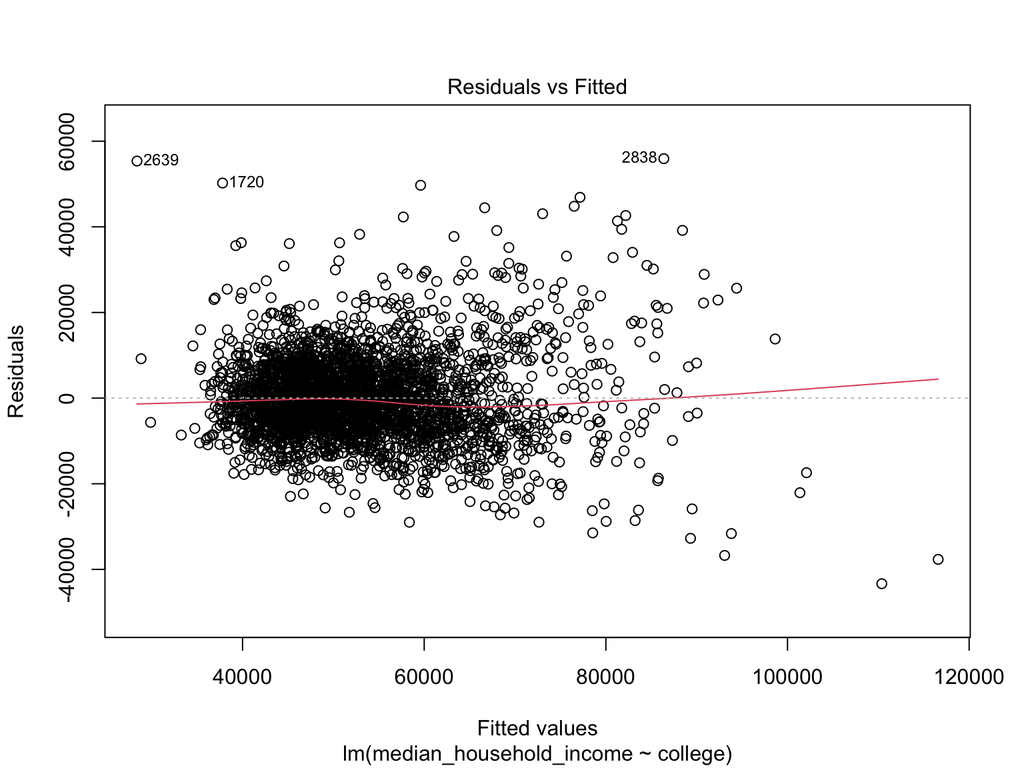

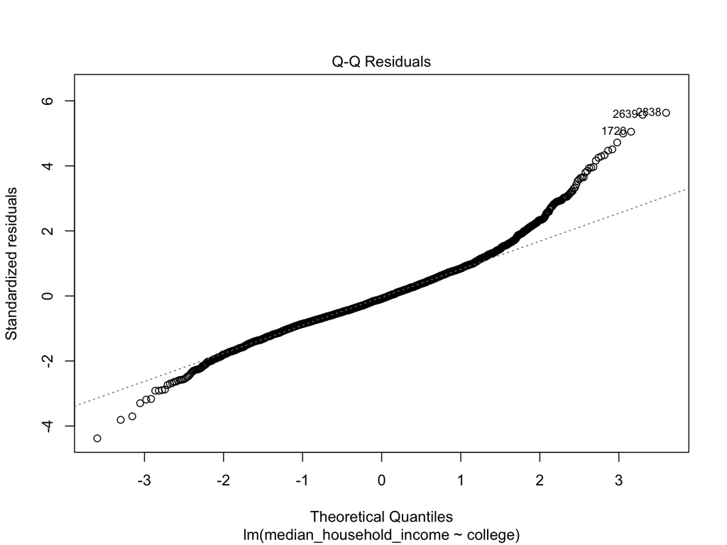

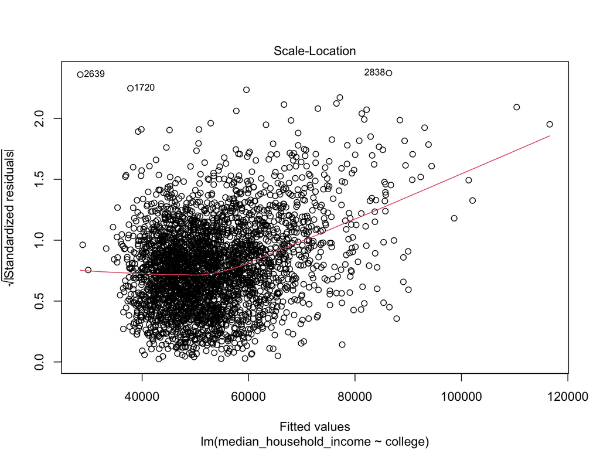

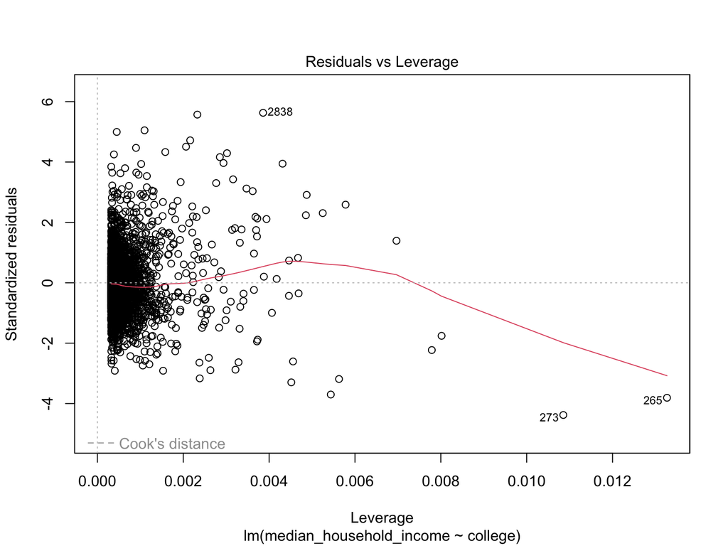

```r
plot(reg1)
```

- The residual plot shows that $\hat{e}_i$ appears to be scattered around zero, the dashed horizontal line. A sign that there are no nonlinear relationships not captured by the model.
- The normal QQ plot is used to visually assess the normality of the residuals (ideally points on the 45 degree line).
- The scale-location plot shows the spread of the residuals over the fitted values (a test of homoskedasticity).
- The residuals vs leverage plot allows you to detect influential observations or outliers that might change the results of the model significantly. These are the observations found *outside* of the Cook’s distance lines.

# Extra: Regression Based Two Sample T-Test.

```r
median_pop <- median(data_analysis$population)
data_analysis <- data_analysis %>% mutate(large_pop = ifelse(population > median_pop, "Large Population", "Small Population"))
```

- With *t.test* command we estimate a two sample t-test that compares the median household income for counties with large population.

```r
# Store Samples Separately
large_pop <- data_analysis %>% filter(large_pop == "Large Population") %>% pull(median_household_income)
small_pop <- data_analysis %>% filter(large_pop == "Small Population") %>% pull(median_household_income)
```

- Run t.test function. Look at the t-stat, the confidence interval

```r
test <- t.test(large_pop, small_pop)
test
```

```
##
##  Welch Two Sample t-test
##
## data:  large_pop and small_pop
## t = 19, df = 2867, p-value <0.0000000000000002
## alternative hypothesis: true difference in means is not equal to 0
## 95 percent confidence interval:
##  8039 9919
## sample estimates:
## mean of x mean of y
##     57786     48807
```

- Mean Difference:

```r
mean_large = test$estimate[1]
mean_small = test$estimate[2]
mean_difference = mean_large - mean_small
mean_difference
```

```
## mean of x
##      8979
```

- With *lm* function we just run a regression the dummy variable that splits the sample.
- Note the coefficient on the dummy captures the mean difference between the two.

```r
lm(median_household_income ~ large_pop, data = data_analysis) %>% summary()
```

```
##
## Call:
## lm(formula = median_household_income ~ large_pop, data = data_analysis)
##
## Residuals:
##    Min     1Q Median     3Q    Max
## -31514  -8719  -1613   6132  84513
##
## Coefficients:
##                           Estimate Std. Error t value            Pr(>|t|)
## (Intercept)                  57786        339   170.4 <0.0000000000000002 ***
## large_popSmall Population    -8979        479   -18.7 <0.0000000000000002 ***
## ---
## Signif. codes:  0 '***' 0.001 '**' 0.01 '*' 0.05 '.' 0.1 ' ' 1
##
## Residual standard error: 13400 on 3105 degrees of freedom
## Multiple R-squared:  0.102,  Adjusted R-squared:  0.101
## F-statistic:  351 on 1 and 3105 DF,  p-value: <0.0000000000000002
```

- Using the fact that we are modelling the conditional mean of $y$ (MHI) on $x$ (large population)

$$\beta_1 = E[MHI |LargePop = 1] - E[MHI
|LargePop = 0]$$

# Extra: Multivariate Regression

- You can add more variables to the regression equation.

```r
reg_model <- lm(formula = vote_rep ~ female + black + median_household_income ,
                data = data_test)

# Show the regression output
reg_model %>% summary()
```

```
##
## Call:
## lm(formula = vote_rep ~ female + black + median_household_income,
##     data = data_test)
##
## Residuals:
##    Min     1Q Median     3Q    Max
## -0.604 -0.113  0.021  0.116  0.461
##
## Coefficients:
##                             Estimate   Std. Error t value             Pr(>|t|)
## (Intercept)              1.305211040  0.058283576   22.39 < 0.0000000000000002
## female                  -0.009472261  0.001160670   -8.16  0.00000000000000048
## black                   -0.004870595  0.000191435  -25.44 < 0.0000000000000002
## median_household_income -0.000003174  0.000000196  -16.17 < 0.0000000000000002
##
## (Intercept)             ***
## female                  ***
## black                   ***
## median_household_income ***
## ---
## Signif. codes:  0 '***' 0.001 '**' 0.01 '*' 0.05 '.' 0.1 ' ' 1
##
## Residual standard error: 0.149 on 3103 degrees of freedom
## Multiple R-squared:  0.221,  Adjusted R-squared:  0.22
## F-statistic:  294 on 3 and 3103 DF,  p-value: <0.0000000000000002
```

# Extra: Download Census Data via Tidycensus

```r
library(tidycensus)
county_data <- get_acs(
  geography = "county",
  variables = c(median_household_income = 'B19013_001',
                female = 'B01001_026',
                population = 'B01003_001',
                age_median = 'B01002_001',
                college_grad = 'B15003_022',
                black = 'B02001_003'),
  year = 2019,
  cache_table = TRUE,
  survey = "acs5"
)

# Clean the data a little bit
county_data_raw <- county_data %>%
  select(-moe) %>%
  rename(county_fips = GEOID) %>%
  mutate(county_fips = as.integer(county_fips))


# export to the csv file
rio::export(county_data_raw,
            here(lab6_path, 'county_data.csv'))
```

# Extra: Clean data GDP by County

- Load data from the BEA. Real GDP by county. *This data is expressed in thousands of dollars*

```r
gdp_data <-rio::import(here(lab6_path, "CAGDP9__ALL_AREAS_2017_2022.csv"))
```

- Lets view the data

```r
glimpse(gdp_data)
```

```
## Rows: 108,052
## Columns: 14
## $ GeoFIPS                <int> 0, 0, 0, 0, 0, 0, 0, 0, 0, 0, 0, 0, 0, 0, 0, 0,…
## $ GeoName                <chr> "United States", "United States", "United State…
## $ Region                 <int> NA, NA, NA, NA, NA, NA, NA, NA, NA, NA, NA, NA,…
## $ TableName              <chr> "CAGDP9", "CAGDP9", "CAGDP9", "CAGDP9", "CAGDP9…
## $ LineCode               <int> 1, 2, 3, 6, 10, 11, 12, 13, 25, 34, 35, 36, 45,…
## $ IndustryClassification <chr> "...", "...", "11", "21", "22", "23", "31-33", …
## $ Description            <chr> "All industry total ", " Private industries ", …
## $ Unit                   <chr> "Thousands of chained 2017 dollars", "Thousands…
## $ `2017`                 <chr> "19612102000", "17156255000", "176840000", "267…
## $ `2018`                 <chr> "20193896000", "17711775000", "184105000", "277…
## $ `2019`                 <chr> "20692087000", "18195752000", "171149000", "314…
## $ `2020`                 <chr> "20234074000", "17761871000", "173659000", "305…
## $ `2021`                 <chr> "21407692000", "18909453000", "183742000", "269…
## $ `2022`                 <chr> "21822037000", "19283116000", "170058000", "245…
```

# Extra: Clean data GDP by County

- GDP data requires several transformations.
- Has information aggregated at the state and national level, contains data on all economic activities, and it is in wide format.
- Hence: we need to drop some observations, and reshape the data.

```r
# clean the gdp data
gdp_data_base <- gdp_data %>%
    # keep only totals by county
  filter(Description == "All industry total ") %>%
  # drop national total
  filter(GeoFIPS != 0) %>%
  # drop irrelevant variables
  select(-c(Region, LineCode, IndustryClassification, Unit, Description, TableName, GeoName))

# Reshape the data
gdp_clean <- gdp_data_base %>%
  # data reshape long
  gather(key = "year", value = "real_gdp", -c(GeoFIPS)) %>%
  # keep only observations from 2019
  filter(year == 2019) %>%
  # rename fips variable
  rename(county_fips = GeoFIPS) %>%
  # drop variable year, we no longer need it
  select(-year) %>%
  # remove observations with missings
  filter(real_gdp != "(NA)") %>%
  # convert to numeric variable
  mutate(real_gdp = as.double(real_gdp))

# Examine the output
gdp_clean %>% head(n = 10)
```

```
##    county_fips  real_gdp
## 1         1000 224944577
## 2         1001   1730861
## 3         1003   8148786
## 4         1005    762557
## 5         1007    441359
## 6         1009   1014620
## 7         1011    266230
## 8         1013    638217
## 9         1015   4555074
## 10        1017    938023
```

# Extra: Clean data Population by County

```r
population_raw <- rio::import(here(lab6_path, 'co-est2019-alldata.csv'))
```

- Examine the data.

```r
names(population_raw)
```

```
##   [1] "SUMLEV"                "REGION"                "DIVISION"
##   [4] "STATE"                 "COUNTY"                "STNAME"
##   [7] "CTYNAME"               "CENSUS2010POP"         "ESTIMATESBASE2010"
##  [10] "POPESTIMATE2010"       "POPESTIMATE2011"       "POPESTIMATE2012"
##  [13] "POPESTIMATE2013"       "POPESTIMATE2014"       "POPESTIMATE2015"
##  [16] "POPESTIMATE2016"       "POPESTIMATE2017"       "POPESTIMATE2018"
##  [19] "POPESTIMATE2019"       "NPOPCHG_2010"          "NPOPCHG_2011"
##  [22] "NPOPCHG_2012"          "NPOPCHG_2013"          "NPOPCHG_2014"
##  [25] "NPOPCHG_2015"          "NPOPCHG_2016"          "NPOPCHG_2017"
##  [28] "NPOPCHG_2018"          "NPOPCHG_2019"          "BIRTHS2010"
##  [31] "BIRTHS2011"            "BIRTHS2012"            "BIRTHS2013"
##  [34] "BIRTHS2014"            "BIRTHS2015"            "BIRTHS2016"
##  [37] "BIRTHS2017"            "BIRTHS2018"            "BIRTHS2019"
##  [40] "DEATHS2010"            "DEATHS2011"            "DEATHS2012"
##  [43] "DEATHS2013"            "DEATHS2014"            "DEATHS2015"
```

[output cut: 40 more lines]

# Clean the Data: Population by County

- If you want to clean all this data set, you need to do something similar to the process we did for the GDP data.
- Since we only want population for 2019, we can simplify things considerably.

```r
population_clean <- population_raw %>%
  # select relevant variables: county identifiers and the population estimate for 2019
  select(STATE, COUNTY, STNAME, CTYNAME, POPESTIMATE2019) %>%
  # we are going to merge using county fips.
  # Note: FIPS code: State fips + county fips
  mutate(st_fips = as.character(STATE),
         cty_fips = as.character(COUNTY)) %>%
  # We need to manually add the preceding zeros. Example: Fips = 1 is coded as "001"
  # First compute the lenght of the codes
  mutate(len_st = nchar(st_fips),
         len_cty = nchar(cty_fips)) %>%
  # add the zeros manually and redefine the variables with the fips codes
  mutate(st_fips = ifelse(len_st == 1, paste("0", st_fips, sep = ""), st_fips),
         cty_fips = case_when(len_cty == 1 ~ paste("00", cty_fips, sep = ""),
                              len_cty == 2 ~ paste("0", cty_fips, sep = ""),
                              len_cty == 3 ~ cty_fips)) %>%
  # create county_fips
  mutate(county_fips = paste(st_fips, cty_fips, sep = "") %>% as.integer()) %>%
  # rename variable population
  rename(population = POPESTIMATE2019) %>%
  # keep only relevant variables
  select(county_fips, population)
```

- View the data

```r
population_clean %>% head(n = 10)
```

```
##    county_fips population
## 1         1000    4903185
## 2         1001      55869
## 3         1003     223234
## 4         1005      24686
## 5         1007      22394
## 6         1009      57826
## 7         1011      10101
## 8         1013      19448
## 9         1015     113605
## 10        1017      33254
```